# Description of Phosphosite Data

Anthony Barente

11/16/2021

## 1. Intro:

Here I provide an introduction to Mario Letutert’s large yeast phospho perturbation dataset. These data were analyzed in DIA mode, searched with spectronaut, and quantified at the site level. Given the scale of the data, 100s of samples split across several replicates, much care in the QC process. In this notebook I will focus on describing basic aspects of the dataset, such as detections and the presence of batch effects.

## 2. Data Used:

Data for this report are available in:

- `yeast_phospho_data_processed/site_data_v2/data_psites.csv`
- `yeast_phospho_data_processed/site_data_v2/data_psites.vfilt.50.csv`
- `yeast_phospho_data_processed/site_data_v2/meta_runs_samples.csv`

## 3. Treatments and Metadata:

The data include samples for 101 treatments split accross 7 measurement batches. Each batch contains a large portion of the total treatments, and all contain at least 1 untreated replicate. In this section we will look at the distribution of runs and treatments.

#### 3.1 Number of runs in individual batches

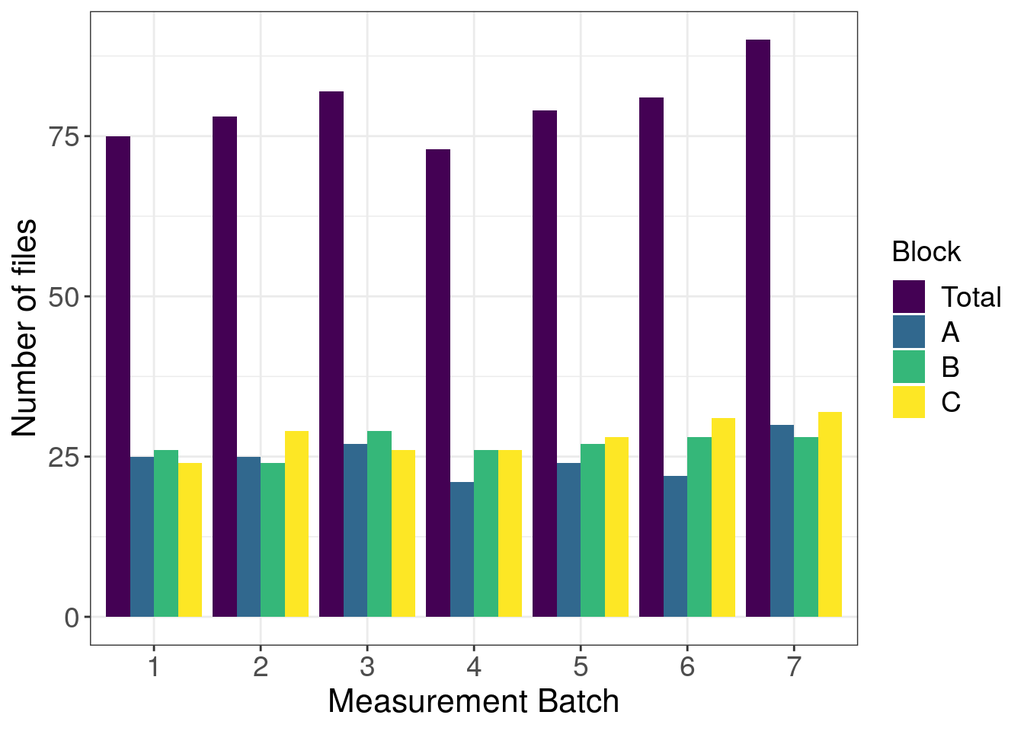

#### 3.2 Treatment presence in batch

[figure not shown]

While no treatment is present in every single batch, most treatments are present in almost all batches. Some treatments with additional missingness contained outlying samples which were screaned elsewhere and left out of subsequent analyses. Given the unbalanced design, care will need to be taken so that we do not introduce unnecessary bias.

## 4. Detections

#### 4.1 Number of detections per run

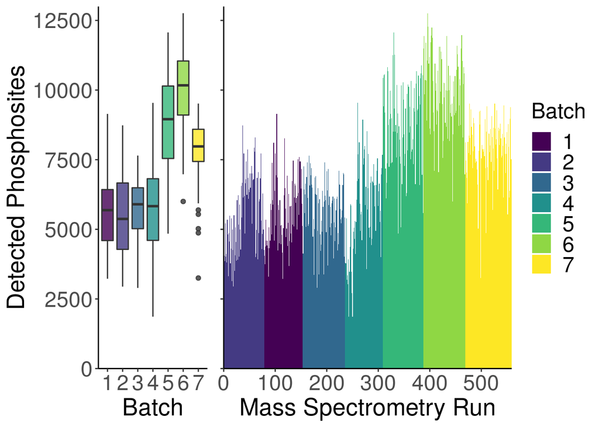

Later batches are of much higher quality identification-wise than earlier batches. This will be an interesting thing to watch out for, since earlier batches will have much more imputation. It is unclear at this point whether this will have an impact on analyses.

#### 4.2 Sites detected by missingness

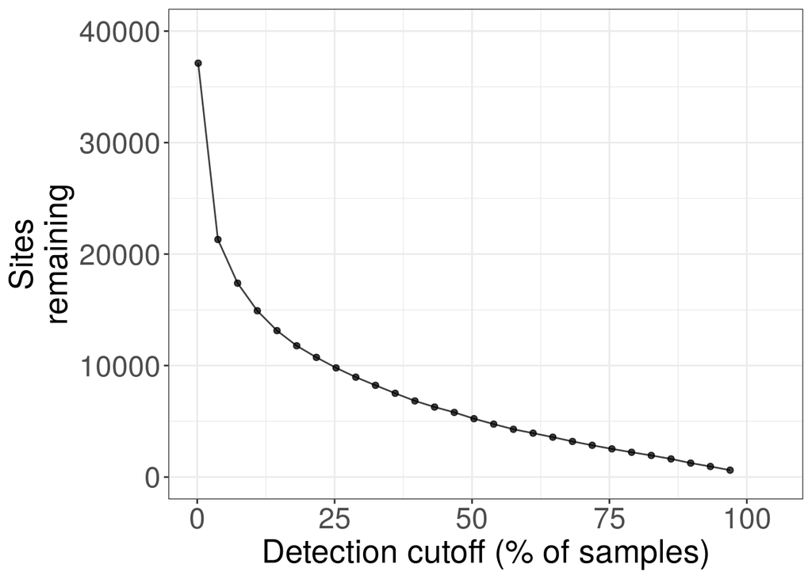

Sites rapidly drop off with increasing stringency on missingness. Our final agreed upon cutoff will be 50% missingness for most analyses. For some analyses, such as that for kinase enrichment analysis, we will be able to ignore missing data.

#### 4.2 Missingness by median intensity

```
## [1] 1
## [1] 2
## [1] 3
## [1] 4
## [1] 5
```

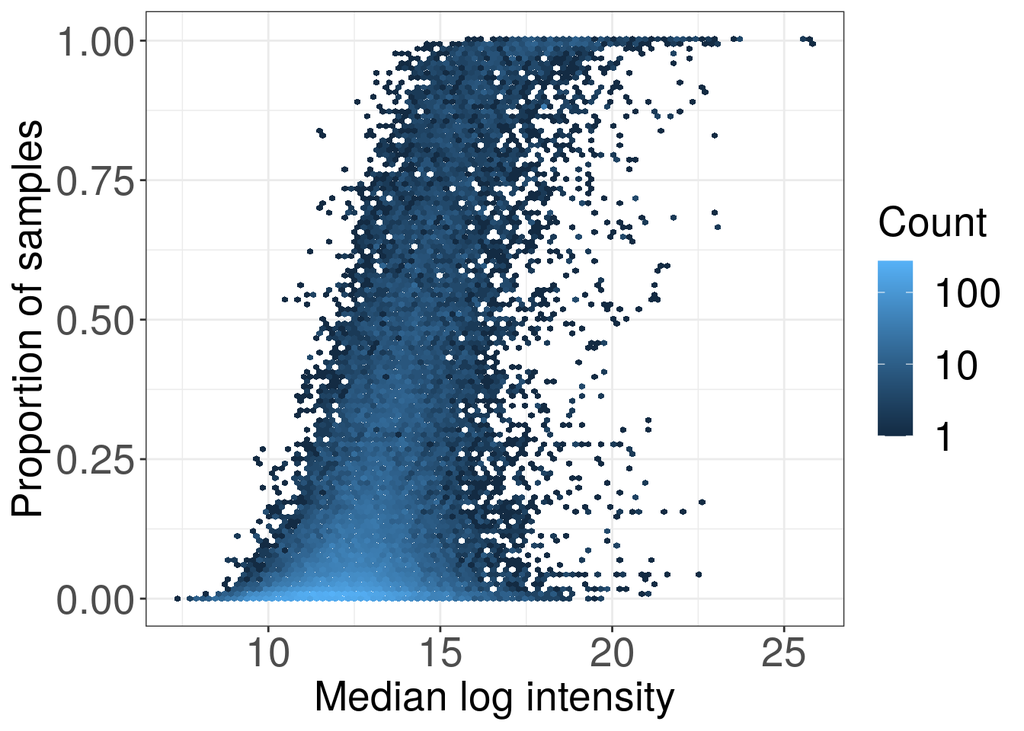

As with most mass spectrometry data, the missingness seems to follow a left censored distribution. After talking to some of our colleagues, we decided QRILC imputation would work well for this dataset. This will give us left censored imputation with some randomness.

#### 4.3 Overview of the final dataset

```
##    dataset count
## 1 Original 37124
## 2 Filtered  5294
```

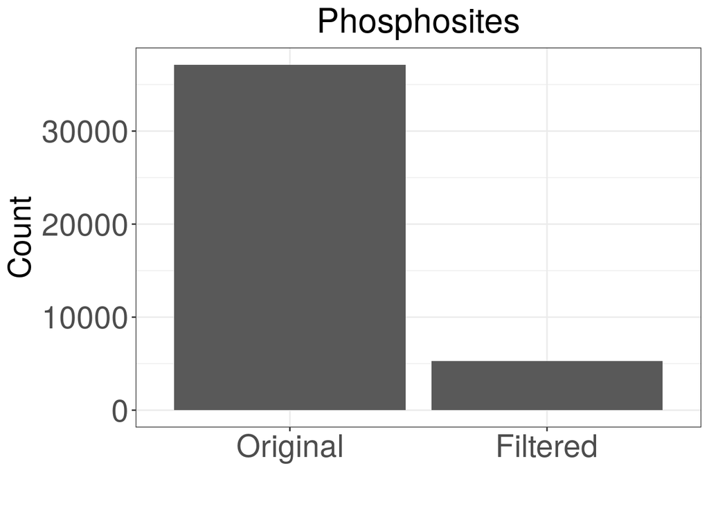

```
##    dataset count
## 1 Original  3121
## 2 Filtered  1390
```

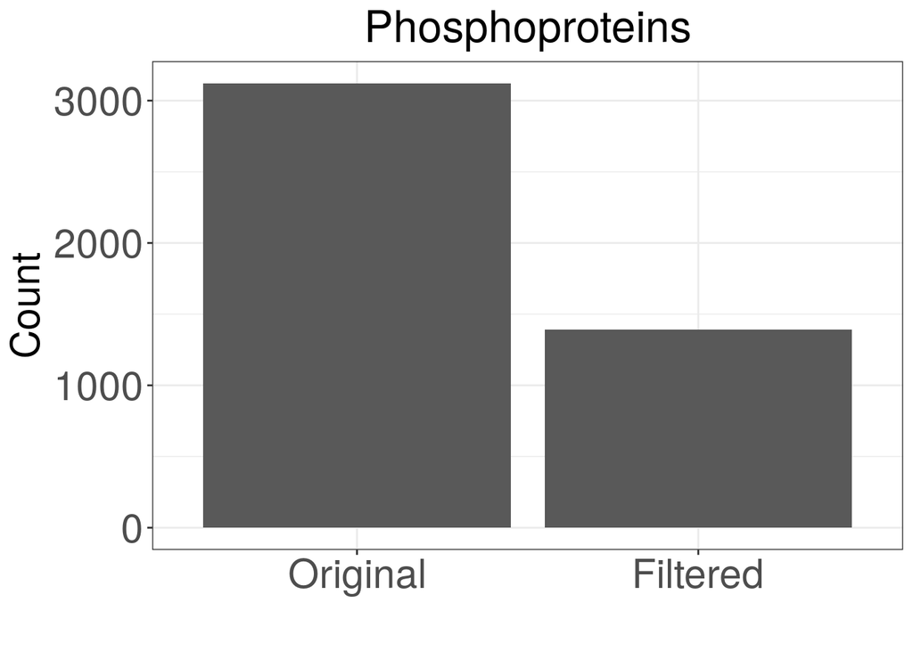